# Homework 12

## Question 1: Design and use an unsupervised-learning skill

Create a reusable skill that directs an AI agent to explore clustering methods, select one, and explain its results in a concise report. Use `data/golub.csv` from the combined ZIP to cluster the 38 biological samples using their 3,051 gene measurements. Each observation is one sample. Use `gene_1` through `gene_3051` as the gene-expression variables; `sample_id` identifies the sample, and `leukemia_type` gives its known class label.

1. **Define the skill.** Write a single `SKILL.md` file no larger than **5 KB (5,000 bytes)**, including YAML `name` and `description` frontmatter. Keep the skill independent of any particular dataset, variable names, or observed results. Provide the data details separately when invoking it, and configure it to load only when explicitly invoked.

   The skill must try **at least three different clustering algorithms**, such as K-means, hierarchical clustering, and spectral clustering. It should guide preprocessing, tuning, the choice of the number of clusters, and the criteria used to compare methods and select a final one. You may include dimension reduction, such as PCA or UMAP, but an embedding alone does not count as a clustering algorithm. Decide how the skill should present the selected clustering visually and interpret the main findings and limitations.

   **The skill must explicitly instruct the agent to limit its generated analysis report to one printed page, including all text, figures, and tables, and to present clustering results from only one selected method.** The report may briefly mention the other methods considered to justify the selection, but must not present their clustering results.
2. **Apply the skill.** Explicitly invoke it to analyze the Golub data and produce a clearly readable report of **no more than one printed page**. Use gene expression for fitting and method selection. If you use the known leukemia-type labels, use them only to interpret the final clustering.

   Briefly name the algorithms considered, explain the selection criteria, and justify the chosen method. **Present clustering results only for the selected algorithm**, including a meaningful visual presentation and an interpretation of the groups. Choose the figures or tables and the key evidence carefully so that the report makes effective use of the limited space.
3. **Review and submit.** Check the analysis and its interpretation. Submit the report as a PDF named `homework-12.pdf` or a self-contained HTML file named `homework-12.html`, and the complete skill as `SKILL.md`, in `homework/week-12/`. Append the complete skill definition after the one-page analysis report; this appendix is outside the one-page limit.

**Answer 1.**

**a.** The skill is `homework/week-12/SKILL.md` (3,695 bytes). Its frontmatter has `name`, `description`, and `disable-model-invocation: true`, so it loads only when invoked by name. It tries K-means, Ward hierarchical clustering, and spectral clustering or a Gaussian mixture, and it requires a one-page report that presents only the selected method. The full file is appended below the report.

**b.** I invoked it with only the data details:

> Use the `cluster-report` skill in `homework/week-12/SKILL.md`. Data: `homework/week-12/data/golub.csv`. Features: `gene_1` to `gene_3051`. ID: `sample_id`. Known label: `leukemia_type`, for interpreting the final clusters only.

The analysis script and outputs are in `skill-run/` (`cluster_analysis.py`, `figure.py`, `criteria.csv`).

### Golub leukemia clustering report

**Data and preprocessing.** 38 samples, 3,051 genes, no missing values. Because p > n, I kept the 1,000 highest-variance genes, standardized them, and clustered on the first 6 PCs, which explain 50.1% of their variance (PC1 17.4%, PC2 9.9%).

**Methods and selection.** I compared K-means (25 starts), Ward hierarchical, and spectral clustering (10-NN affinity) for K = 2 to 7, using mean silhouette width and stability (mean adjusted Rand index against refits on 50 random 80% subsamples; seed 432). The rule keeps stability ≥ 0.75, takes the highest silhouette, and breaks ties within 0.02 by smaller K, then the simpler method. It selected **K-means, K = 3** (silhouette 0.300, stability 0.969). Spectral K = 3 tied on silhouette but was less stable (0.934). Ward’s best (K = 3, 0.288) failed the stability cut (0.742), and K-means K = 6 (0.302) lost the tie to smaller K.

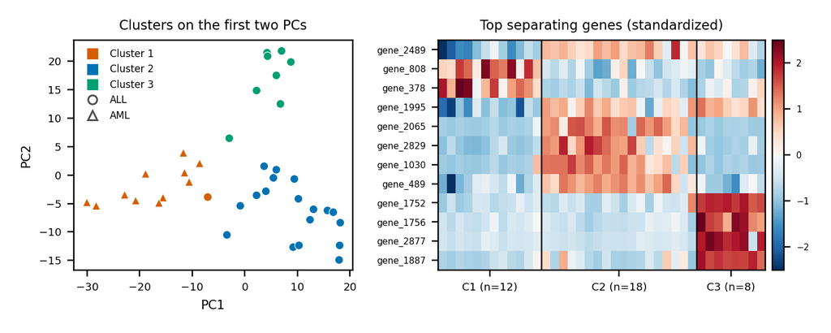

Left: K-means clusters on PC1 and PC2 (marker shape = known type, added after fitting). Right: the four most distinctive genes per cluster, standardized.

| Cluster | n | ALL | AML | Mean silhouette |
| --- | --- | --- | --- | --- |
| 1 | 12 | 1 | 11 | 0.302 |
| 2 | 18 | 18 | 0 | 0.206 |
| 3 | 8 | 8 | 0 | 0.509 |

**Interpretation.** The known labels were not used in fitting. Cluster 1 contains all 11 AML samples and 1 ALL sample, and it sits apart from the rest along PC1. Clusters 2 and 3 split the ALL samples, so the adjusted Rand index with the two-type label is only 0.508, though just 1 of 38 samples sits in a cluster dominated by the other type. Cluster 3 is the tightest group (silhouette 0.509) and is defined by four genes that are strongly elevated only there (standardized mean differences of 2.2 to 2.3). Its size matches the 8 T-cell ALL samples the original study reports for these 38 samples, so it plausibly captures that subtype, but the supplied labels cannot confirm it.

**Limitations.** With 38 samples, stability comes from subsamples of the same data, and the gene filter and 50% PCA cut could shift the clusters. Genes are identified only by index, which limits biological interpretation.

### Review and appendix

**c. Review.** Before running the skill, I fixed one design error: it originally standardized genes before keeping the highest-variance ones, which makes every variance equal to 1. I checked the following against the script output:

- The labels were read only after the clustering was chosen.
- All three methods used the same 6 PC scores and the same 50 subsamples.
- The selection follows the stated rule.
- Every number in the report matches the printed output.

The T-cell interpretation relies on the original study’s description, not on these data.

**Complete `SKILL.md`:**

```markdown
---
name: cluster-report
description: Explore several clustering algorithms on a user-supplied dataset, select one, and write a one-page report. Use only when the user explicitly invokes cluster-report by name.
disable-model-invocation: true
---

# Clustering analysis report

## Inputs (from the user's message)

Data file, the feature columns to cluster, an ID column, any known label column, and a seed (default 432). Ask once if the features are unclear. Never cluster on IDs or labels.

## Rules

- Fit, tune, and select using the features only. A known label may be used only after the final method is chosen, to interpret its clusters. Never use it to pick a method, K, or preprocessing.
- Report only numbers you computed in this run. Set the seed for every random step.

## Steps

1. **Check the data.** Report n, p, missing values, and feature scales. Stop and ask if features are missing.
2. **Preprocess.** If p > n, first keep the 1,000 features with the highest variance on their original scale (or all, if fewer). Then standardize each kept feature (mean 0, SD 1), compute PCA, and cluster on the first d component scores, where d is the smallest number explaining 50% of the variance (at least 2, at most 20). If p ≤ n, skip the filter and PCA, and cluster the standardized features. Report the filter, d, and the variance explained.
3. **Algorithms.** Fit at least three:
   - K-means (25 random starts),
   - agglomerative hierarchical clustering with Ward linkage,
   - one non-centroid method, preferably spectral clustering with a nearest-neighbor affinity, or a Gaussian mixture.
4. **Number of clusters.** For each algorithm, try K = 2 to min(8, n/5).
5. **Criteria.** For each algorithm and K, compute:
   - the mean silhouette width in the clustering space;
   - stability: refit on 50 random subsamples of 80% of the rows and average the adjusted Rand index (ARI) with the full-data labels on the shared rows.
6. **Selection.** Keep candidates with stability ≥ 0.75. Among those, choose the highest silhouette. If several are within 0.02 of it, prefer smaller K, then the simpler method (K-means, then hierarchical, then the rest). If none reach 0.75, choose the most stable and say the structure is weak.
7. **Interpret.** For the selected clustering only, report cluster sizes, the features that most separate the clusters (largest standardized mean differences, top 5 to 10), and, if a known label exists, a cluster-by-label table and the ARI with it.

## Report: one printed page, Letter size, 11-point text

The whole report, including all text, figures, and tables, must fit on one printed page. Present clustering results from the selected method only. Mention the other methods in one or two sentences, with their best silhouette and stability values, only to justify the choice. Do not show their cluster assignments, plots, or tables.

Order:

1. **Data and preprocessing** (2 sentences).
2. **Methods and selection** (2 to 3 sentences), naming the algorithms, the K range, the criteria, and the rule.
3. **Figure** (about 6.5 × 2.6 in): left, the selected clusters on the first two PCs; right, silhouette widths of every observation by cluster, or a heat map of the top separating features. Use colorblind-safe colors and plain axis labels.
4. **Table**: cluster sizes and, if available, the cluster-by-label counts.
5. **Interpretation** (3 to 4 sentences): what distinguishes the clusters, and how well they match any known label.
6. **Limitations** (2 sentences).

Write a self-contained HTML or PDF plus the analysis script. Print to Letter at 11 pt and shorten until the report fits on one page. Every number in the text must match printed output.
```